# 住宅価格と住宅政策

岩田真一郎（神奈川大学経済学部）

2023-01-20作成，2025-06-29改訂

［PDF形式：1041KB］

ここでは，住宅価格が住宅市場でどのように決定されるのかを理解するために，住宅の需要曲線と供給曲線について学んでいきます．これらはミクロ経済学入門の応用になります．次に，日本では，政府が様々な住宅政策を用いて市場介入していますが，これらの政策の影響を主に効率性の観点から経済学的に検討します．最後に，空き家の価格付け，住宅の所有価格と賃貸価格の相違と関係について説明します．

# 1 個別需要曲線，消費者余剰，市場需要曲線

住宅は住宅メーカーや不動産デベロッパーなどの生産者から購入して居住することもできますし，家主から賃貸して居住することもできます．所有と賃貸の違いを考えるときには，時間の概念が大事になります．住宅のような耐久財の所有価格は，現在から将来にわたる収益を反映する賃貸価格に依存するからです．ここでは，しばらくの間，所有と賃貸の違いを無視して分析を進めす．所有価格と賃貸価格の違いや関係性は第$5$節（$2$）で取り扱います．

以下では，住宅市場は**完全競争市場**として仮定して分析を進めます．完全競争市場とは，消費者の数も生産者の数も極めて多く，取引されている財が同質であるような市場をさします．住宅を購入しようとする消費者や住宅を販売しようとする生産者は多数存在するため，一つ目の仮定は問題ないでしょう．しかし，住宅は所有か賃貸かの違いに加えて，建て方（一戸建，共同），構造（木造，鉄骨・鉄筋コンクリート），立地場所（都心，郊外）など，さまざまな次元で製品差別化されているのが一般的で，二つ目の仮定は成立しそうにありません．このような異なる属性を考慮して住宅価格がどのように決定されるのかを分析するモデルとして**ヘドニックモデル**が存在しますが，ここでは取り扱いしません．ヘドニックモデルについては，**[住宅価格の推定：ヘドニックモデルの理論と実証](https://shinichiro-iwata.github.io/lecture-notes-urban-econ/hedonic-model.html)**を参考にしてください．また，立地場所の違いによる住宅価格の違いについては**[都市内の住宅立地](https://shinichiro-iwata.github.io/lecture-notes-urban-econ/residential-location-choice)**で分析します．

ここでは，同質的な住宅の取引を考えます．ただし，市場に参加する消費者や生産者は住宅の面積を決めることはできるとします．このことは，住宅の取引単位は住宅の面積になることを意味します．市場で決定される住宅価格は面積あたりの住宅価格であり，面積を含む住宅価格ではありません．例えば，消費者が購入した住宅に対して支払う金額（支出）は，住宅価格×購入面積になります．

完全競争市場では，個々の消費者と生産者は単独では住宅価格に影響を与えられず（**価格受容者**），与えられた住宅価格に対して，消費者は住宅消費量を，生産者は住宅生産量を決定します．

最初に，住宅消費を考えるある消費者の行動を分析しましょう．図$1$のように縦軸に住宅価格，横軸に住宅消費量を測ると，住宅価格の変動は住宅消費量にどのような影響をもたらすでしょうか．経済学では，財やサービスの価格が低下するとその財やサービスの消費量は増加すると考えています．この様子を描いた消費者の個別**需要曲線**は図$1$の$d$のように右下がりの曲線になります．なお，需要曲線$d$は直線で描かれていますが，直線も曲線の一種であることに留意してください．図$1$では，住宅価格が$P_1$の場合，消費者は住宅を$h_1$単位消費し，価格が$P_0$に下落すると，消費量を$h_0$単位に増やすことが示されています．

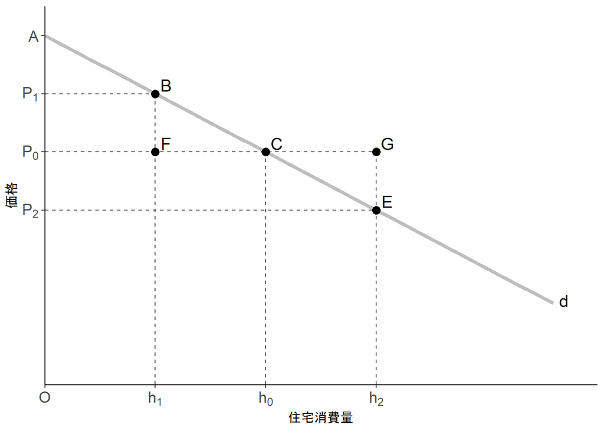

図1：個別需要曲線

経済学では，消費者は合理的に行動すると仮定します．ここでは，取引からの純利益を示す**消費者余剰**の概念を利用して，住宅価格が$P_0$の場合，$h_0$単位の住宅を選択することが消費者余剰を最大にする合理的（最適）な選択になることを示しましょう．消費者が住宅消費から得られる便益を金銭評価できると仮定し，その便益から実際に支払った額（支出）を引いた値を次の$(\ref{cs})$式のように消費者余剰と定義します．

$$消費者余剰＝便益-支出　\label{cs}\tag{1}$$
便益はゼロ（$O$）から消費量までの需要曲線$d$の下の面積で測られ，支出は価格と消費量の積を示す面積で測られます．したがって，住宅価格が$P_0$のときに消費者が住宅を$h_0$単位消費すると，消費者余剰は，便益を示す面積$ACh_0O$から支出を示す面積$P_0Ch_0O$を差し引いた，面積$ACP_0$になります．仮に，価格が$P_0$のときに$h_1$単位しか消費しないとしましょう．このとき，便益は面積$ABh_1O$に，支出は面積$P_0Fh_1O$に，消費者余剰は面積$ABFP_0$になります．したがって，消費者余剰は$h_0$単位消費するときに比べて面積$BCF$だけ小さくなります．今度は，価格が$P_0$のときに$h_2$単位も消費する場合を取り上げましょう．このとき，便益は面積$AEh_2O$に，支出は面積$P_0Gh_2O$になるため，消費者余剰は$h_0$単位消費するときに比べて面積$CGE$だけ小さくなります．以上をまとめると，価格$P_0$のとき，$h_0$単位より消費量を増やしても減らしても消費者余剰は減少してしまいます．このことは，$h_0$単位を選択することが合理的であることを意味します．

個別需要曲線から市場需要曲線を求めるために，これまで述べてきた消費者と同質的な消費者が$N$（例えば，$N$人）存在するとしましょう．価格が$P_1$のとき，ある消費者が$h_1$単位消費していたとすると，他の同質的な消費者も同じく$h_1$単位消費することになります．したがって，価格が$P_1$のとき，市場全体の消費量は$N×h_1$単位になります．価格が$P_0$に低下すると，消費者の消費量は$h_0$に増えるため，市場全体の消費量も$N×h_0$単位に増加します．すべての価格について同じことが言えるため，市場需要曲線も個別需要曲線同様に，価格が低下すると消費量が増加する右下がりの曲線になります．

# 2 個別供給曲線，生産者余剰，市場供給曲線

次に，住宅供給を考えるある生産者の行動の分析に移りましょう．縦軸に住宅価格，横軸に住宅生産量を測ると，住宅価格の変動は住宅生産量にどのような影響をもたらすでしょうか．経済学では，財やサービスの価格が上昇するとその財やサービスの生産量は増加すると考えています．この様子を描いた生産者の個別**供給曲線**は図$2$の$s$のように右上がりの曲線になります．例えば，住宅価格が$P_2$の場合，生産者は住宅を$h_1$単位生産し，価格が$P_0$に上昇すると，生産量を$h_0$単位に増やします．

生産者は，取引からの純利益を示す**生産者余剰**を最大にするように行動すると考えると，住宅価格が$P_0$の場合，$h_0$単位の住宅を選択することが合理的になります．生産者余剰とは，次の$(\ref{ps})$式のように収入から費用を引いた値と定義されます．

$$生産者余剰＝収入-費用　\label{ps}\tag{2}$$

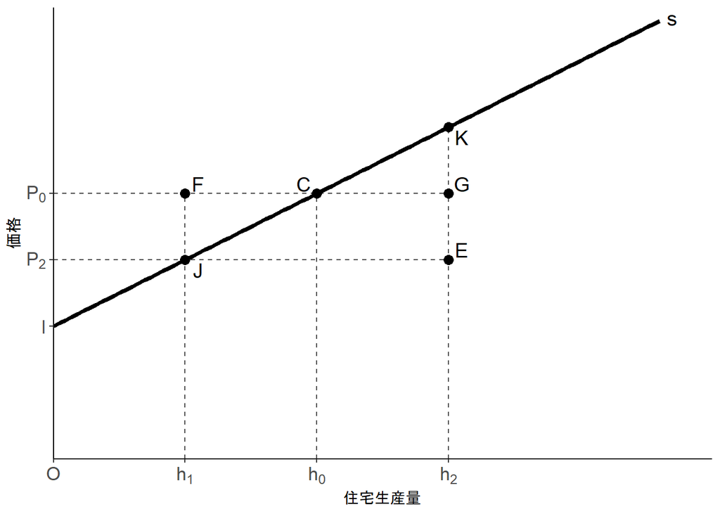

図2：個別供給曲線

収入は価格と生産量の積になり，費用はゼロ（$O$）から生産量までの供給曲線$s$の下の面積で測られます．したがって，住宅価格が$P_0$の場合に生産者が住宅を$h_0$単位生産すると，生産者余剰は，収入を示す面積$P_0Ch_0O$から費用を示す面積$ICh_0O$を差し引いた，面積$ICP_0$になります．仮に，価格が$P_0$のときに$h_1$単位しか生産しないとしましょう．このとき，収入は面積$P_0Fh_1O$に，費用は面積$IJh_1O$に，生産者余剰は面積$IJFP_0$になります．したがって，生産者余剰は$h_0$単位生産するときに比べて面積$JCF$だけ小さくなります．今度は，価格が$P_0$のときに$h_2$単位も生産してしまう場合を取り上げましょう．このとき，収入は面積$P_0Gh_2O$に，費用は面積$IKh_2O$になるため，生産者余剰は$h_0$単位生産するときに比べて面積$CGK$だけ小さくなります．以上をまとめると，価格が$P_0$のとき，$h_0$単位より生産量を増減すると生産者余剰は減少してしまいます．したがって，生産者にとっては$h_0$単位を選択することが合理的になります．

個別供給曲線から市場供給量曲線を求めるために，これまで述べてきた生産者と同質的な生産者が$M$（例えば，$M$社）存在するとしましょう．価格が$P_2$のとき，ある生産者が$h_1$単位生産していたとすると，他の同質的な生産者も同じく$h_1$単位生産することになります．したがって，価格が$P_2$のとき，市場全体の生産量は$M×h_1$単位になります．価格が$P_0$に上昇すると，ある生産者の生産量は$h_0$に増えるため，市場全体の生産量も$M×h_0$単位に増加します．したがって，市場供給曲線も個別供給曲線同様に，価格が上昇すると生産量が増加する右上がりの曲線になります．

# 3 住宅市場の効率性

図3には住宅の市場需要曲線$D_0$と市場供給曲線$S_0$が描かれています．需要と供給が等しくなる市場均衡はこの二本の曲線の交点$C$で決定します．交点$C$は**均衡点**とよばれ，均衡点に対応する価格$P_0$と取引量$H_0$はそれぞれ**均衡価格**と**均衡取引量**とよばれます．

市場全体の消費者余剰と生産者余剰の求め方は個別消費者の消費者余剰と個別生産者の生産者余剰の求め方と同じです．したがって，均衡点における消費者余剰は面積$ACP_0$になり，生産者余剰は面積$ICP_0$になります．経済学は資源配分に無駄が生じていないかを効率性で測ります．ある一つの財またはサービスの取引に注目する**部分均衡分析**では，この効率性を**社会的余剰**で計算し，社会的余剰が大きいほど効率性が高いと考えています．社会的余剰は次の$(\ref{sw1})$式のように消費者余剰と生産者余剰の和として表現されます．
$$社会的余剰＝消費者余剰＋生産者余剰　\label{sw1}\tag{3}$$

したがって，図$3$では社会的余剰は面積$ACI$で測られます．

社会的余剰は次の$(\ref{sw2})$式から求めることもできます．

$$社会的余剰＝便益-費用　\label{sw2}\tag{4}$$
消費者の支出は生産者の収入に等しいため，$(\ref{cs})$式（消費者余剰）と$(\ref{ps})$式（生産者余剰）を足し合わせると上の$(\ref{sw2})$式を得ることができます．

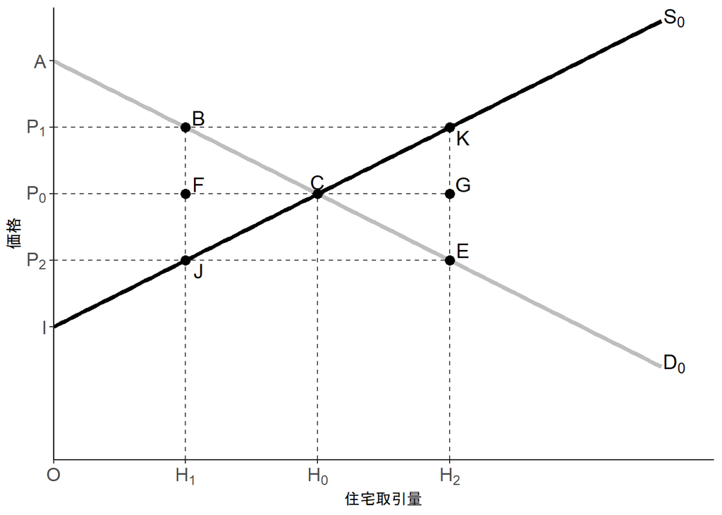

図3：市場需要曲線，市場供給量曲線，住宅市場の均衡

完全競争市場では，均衡点における社会的余剰が最大になることが知られています．このことを確認するために，$(\ref{sw2})$式を用いて，取引量$H_1$および取引量$H_2$における社会的余剰を求めてみましょう．均衡取引量より少ない取引量$H_1$の場合，便益は面積$ABH_1O$に，費用は面積$IJH1_O$になります．社会的余剰は便益から費用を差し引いた面積$ABJI$になるため，均衡取引量$H_0$における社会的余剰に比べて面積$BCJ$だけ小さくなります．均衡取引量より多い取引量$H_2$の場合，便益は面積$AEH_2O$に，費用は面積$IKH_2O$になります．社会的余剰は面積$ACI-CKE$になるため，均衡取引量$H_0$における社会的余剰に比べて面積$CKE$だけ小さくなります．以上から，均衡点（均衡取引量$H_0$）において社会的余剰は最大になります．

# 4 政府の介入

住宅市場では，政府が介入することで，価格が均衡価格と乖離したり，取引量が均衡取引量と乖離したりすることがしばしばあります．そこで，本節では，政府の介入が価格，取引量，各種余剰に対してどのような影響を及ぼすのかを考察します．

## （1）土地利用規制

最初に，住宅供給量を規制する政策について分析してみましょう．日本では土地利用規制によって自由に住宅を建てることはできません．まず，都市の範囲が都市計画区域として定められており，この区域内に住宅を建てる必要があります．次に，都市計画区域は市街化区域と市街化を抑える市街化調整区域に区分けされているため（区域区分制度），住宅を建設できる場所は市街化区域内に狭まります．さらに，市街化区域では建物の用途や形態（高さ，広さ）を制限する規制（地域地区制）が存在します．

図$4$は渋谷区の容積率（敷地面積に対する建物の床面積の割合）を可視しています．商業地である山手線駅周辺は相対的に容積率が高く，高い建物を建築できますが，住宅地では容積率が低いため，低い建物しか建築できません．

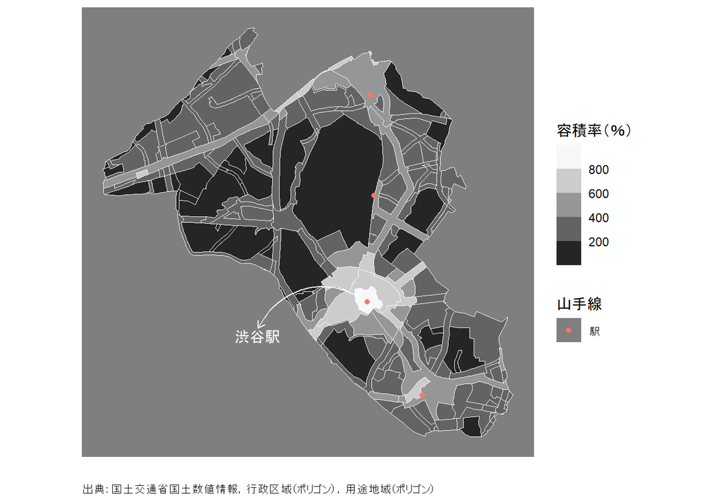

図4：渋谷区の容積率（2019年度）

図$5$は土地利用規制によって，住宅供給量が均衡取引量より少ない$H_1$単位に制限された場合を表しています．価格が$P_2$に達するまでは，生産者は供給曲線$S_0$に沿って住宅を供給します．しかし，規制の下では，取引量が$H_1$単位に制限されているため，価格が$P_2$より高くなっても，生産者は供給曲線$S_0$に沿って住宅供給量を増加できません．すなわち，価格が$P_2$より高い場合，住宅供給量は常に$H_1$単位に固定されることになります．このため，規制後の供給曲線は$S_1$のように変化（シフト）し，住宅価格は$P_0$から$P_1$に上昇します．

土地の希少性を反映して，大都市ほど高層マンションの建設動機が存在しますが，このような形態の建物こそ容積率の影響を受けやすくなります．このため，大都市ほど，規制の影響によって，価格の高騰を招きやすくなると考えられます．

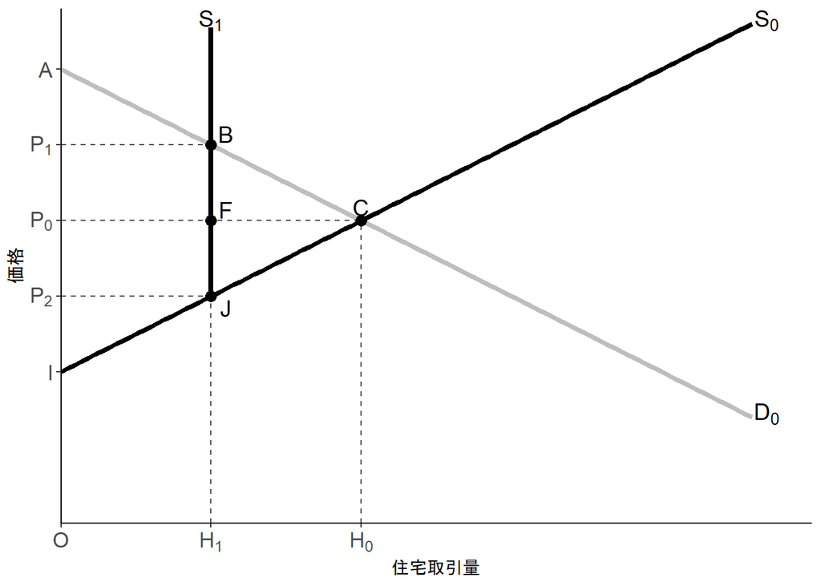

図5：土地利用規制の効果

規制の下では，消費者余剰が面積$ABP_1$に，生産者余剰が面線$IJBP_1$になります．社会的余剰は面積$ABJI$になるため，均衡取引量$H_0$における社会的余剰に比べて面積$BCJ$だけ小さくなります．このことは，住宅市場が完全競争市場の場合，土地利用規制による供給制限は効率性の面から望ましくないと考えられます．

それでは，なぜ効率性が悪化するにも関わらず土地利用規制が存在するのでしょうか．その理由として，土地利用規制によって**外部性**を制御することが挙げられます．外部性や外部性が存在するときの土地利用規制の有効性については第$4$節で分析します．

## （2）住宅取得促進政策

次に，住宅取得を促進する減税（補助金）政策について考えてみましょう．住宅借入金等特別控除は，住宅取得のために銀行借入れした消費者の負担軽減を図るための制度です．住宅ローン残高の一定割合が一定期間に渡り所得税の額から控除される仕組みになっており，住宅ローン減税や住宅ローン控除の通称で普及しています．この住宅ローン減税は景気刺激策の一環として行われる傾向にあります．

住宅取得に関する減税は住宅取得に関する一種の補助金と考えることができます．そこで，住宅を$1$単位消費するごとに$a$の大きさの補助金が消費者に与えられるとして分析を進めよう．補助金によって消費者は住宅消費$1$単位につき$a$だけ余計に支払えるようになるため，補助後の需要曲線は図$6$の$D_1$のようにちょうど$a$だけ上方シフトします．この結果，住宅価格は$P_0$から$P_1$に上昇し，均衡取引量は$H_0$から$H_2$に増加します．

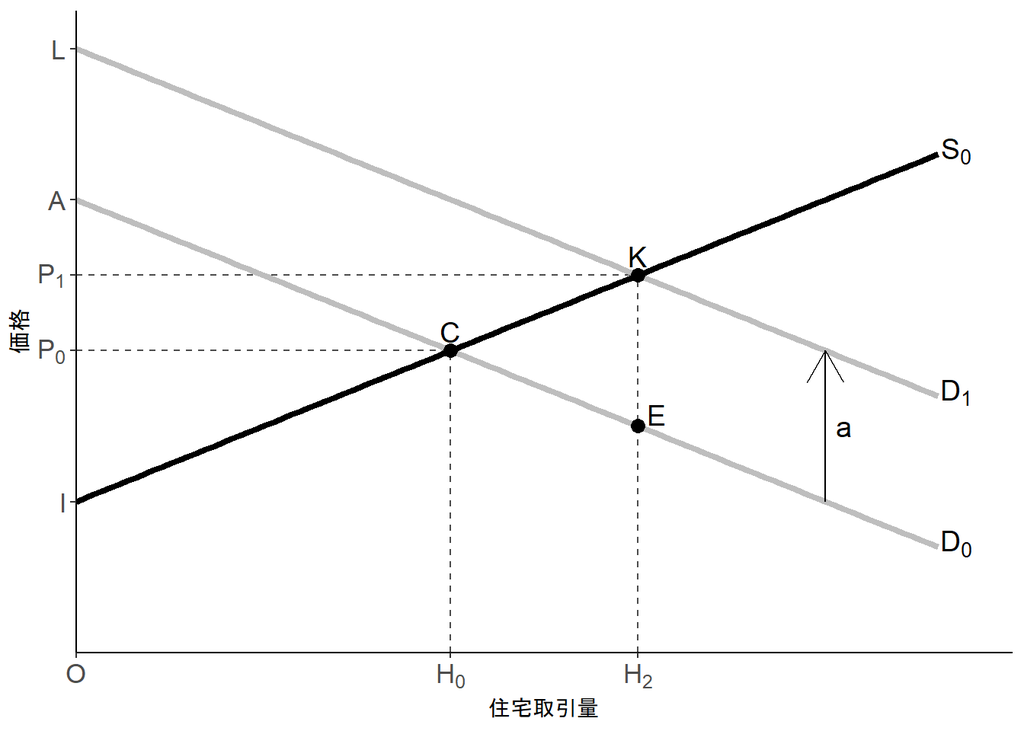

図6：住宅取得促進政策の効果

補助金の下では，消費者余剰は面積$LKP_1$に増加し，生産者余剰は面積$IKP_1$に増加します．しかし，社会的余剰は増加しません．なぜなら，補助金のような支援策は他の誰かの負担によってまかなわれているため，その分を社会的余剰から差し引かなければならないからです．図$6$では，平行四辺形の面積$LKEA$（$a×H_2$）が補助金の総額になります．したがって，社会的余剰は面積$ACI-CKE$になり，補助金がない場合の社会的余剰に比べて面積$CKE$だけ小さくなります．住宅市場が完全競争市場の場合，補助金は効率性の面から望ましくないのです．

補助金のような効果をもつ住宅ローン減税は，消費者や生産者の余剰を増加するため，住宅取引に参加する主体には人気のある制度です．しかし，住宅ローン減税よる取引の増加は，他の主体の負担の上に成り立っていることに注意する必要があります．

## （3）家賃規制と公営住宅供給

次に，低所得層向けの賃貸住宅を確保しようとする住宅政策として家賃規制と公営住宅供給を考えましょう．家賃規制は，家賃の上限を設けることによって借家人の家賃負担の軽減を目指す政策です．図$7$において，家賃が均衡家賃$R_0$よりも低い$R_2$に規制されると，消費者の住宅消費量が$H_2$単位まで増加し，消費者に利益をもたらしそうです．しかし，この規制は，生産者の賃貸住宅生産・経営意欲を阻害します．規制家賃$R_2$の下では，生産者余剰を最大にする住宅供給量は$H_1$単位にとどまります．規制後の取引量は，需要と供給の少ない方に制限されるため，規制前の均衡取引量$H_0$よりも減少します．この意味で，賃貸住宅に入居を希望する低所得者がすべて住居を確保できるとは限らず，家賃規制の目的は必ずしも達成できません．

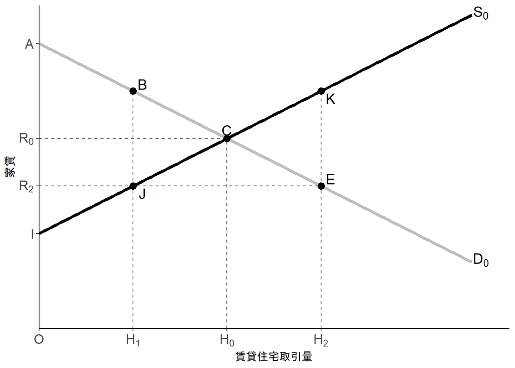

図7：家賃規制と公営住宅供給の効果

家賃規制は効率性の観点からも問題があります．市場は需要が供給を上回る超過需要の状態に陥りますが，家賃は$R_2$より上昇できません．このため，誰がどれだけの住宅を消費するのかという資源配分の問題を価格調整とは異なる方法で解決しなくてはなりません．さらに，誰がどれだけの住宅を消費するのかで消費者余剰の大きさも異なってきます．そこで，家賃規制の下で消費者余剰が最大になる場合を考えましょう．便益が需要曲線の下の面積で測られることに注意すると，需要曲線の高さが最も高くなる縦軸上の切片から順に住宅を配分したほうが消費者余剰は大きくなります．そこで，$H_1$単位の住宅供給量を縦軸上の切片から順に配分していきます．すると，便益は面積$ABH_1O$になります．消費者の支出（総家賃）は規制（単位）家賃$R_2$と住宅消費量$H_1$の積になるため，面積$R_2JH_1O$になります．したがって，消費者余剰は面積$ABJR_2$になります．一方，生産者余剰は面積$IJR_2$になります．社会的余剰の面積は消費者余剰の面積と生産者余剰の面積の合計$ABJI$になり，規制前の社会的余剰に比べて面積$BCJ$だけ小さくなります．

家賃規制は超過需要を発生させ，当初の目的を果たせないことから，日本を含めて多くの国で採用されていません．

低所得者層向けの安価な賃貸住宅は，実際には地方政府による公営住宅の直接供給によってまかなわれています．ここでは，高橋（$2012$）を参考に図$7$に公営住宅の分析を加えます．図$7$で，家賃が均衡家賃$R_0$よりも低い$R_2$のままだと，先に述べたように$H_2-H_1$単位の超過需要が発生します．この超過需要に等しい公営住宅を地方政府が生産者に替わって市場に供給すれば，安い家賃のまま超過需要を解消できます．しかし，この場合も効率性の観点からは問題が生じます．公営住宅の供給によって，消費者余剰は面積$AER_2$に増加します．一方，政府の余剰は，収入を示す面積$JEH_2H_1$が費用を示す面積$JKH_2H_1$を下回るため，面積$JKE$だけ赤字になります．この赤字は他の誰かの負担によってまかなわれない限り公営住宅の生産・運営が成り立ちません．社会的余剰は消費者余剰の面積$AER_2$，生産者余剰の面積$R_2JI$，政府のマイナスの余剰面積$JKE$の合計面積$ACI-CKE$になり，公営住宅がない場合の社会的余剰に比べて面積$CKE$だけ小さくなります．

## （4）負の外部性と土地利用規制

最後に，土地利用規制を再考しましょう．第$4$節（$1$）では，土地利用規制を課す理由として外部性の制御を挙げました．外部性とは，ある主体の行動が市場を経由せずに他の主体の厚生に影響を及ぼすことをいいます．特に，その影響が悪影響の場合は負の外部性とよびます．そこで，第$4$節（$4$）では建物が負の外部性を発生する場合の土地利用規制の効果を分析します．

ある地域の住宅市場において，建物を高く建設しないと，取引量を増やすことはできないとしましょう．市場均衡は図$8$の需要曲線$D_0$と供給曲線$S_0$の交点$C$で決定され，建物の高さは$H_0$単位（例，$H_0$メートル）に達します．

この建物内の物件取引は消費者と生産者の間で行われますが，取引に参加していない周辺住民に対して，生産者が建物を$1$単位高くするごとに$z$の大きさの負の外部性を発生するとしましょう．例えば，建物が高くなることで周辺住宅の日照時間が短くなることなどが考えられます．周辺住民が被る負の外部性を生産者が補償するならば，生産者は高さ$1$単位につき$z$を補償しなければなりません．その結果，供給曲線は$S_0$から$S_1$のように上方シフトし，需要曲線$D_0$と供給曲線$S_1$の交点は$B$点に移動し，建物の高さは$H_1$単位に低下します．これから見るように，$B$点において社会的余剰が最大になるため，$B$点を**最適点**とよぶことにします．

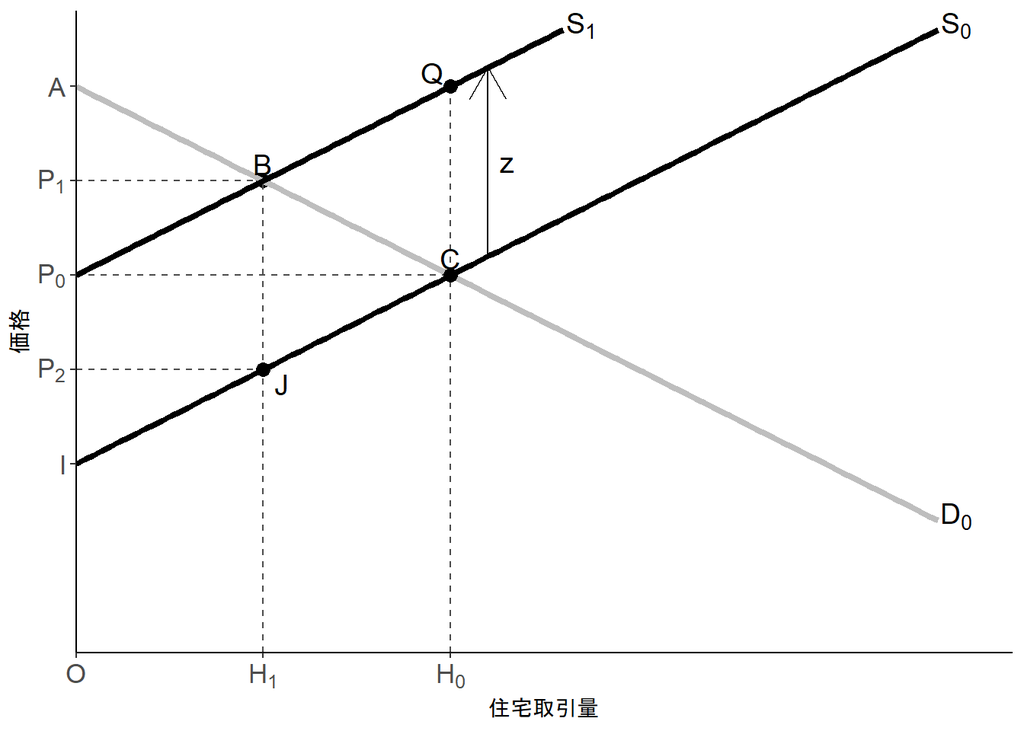

図8：負の外部性と土地利用規制の効果

建物の高さがゼロのとき，周辺住民は何ら影響を受けないため，周辺住民の厚生（余剰）はゼロと基準化できます．最適均衡では，消費者余剰は面積$ABP_1$に，生産者余剰は面積$P_0BP_1$になります．周辺住民は，建物の高さが$H_1$単位になるため，平行四辺形の面積$IJBP0（z×H_1）$の迷惑費用（これを**外部費用**とよびます）を被りますが，生産者によって外部費用は補償されるため，周辺住民の余剰は建物の高さがゼロのとき同様ゼロになります．したがって，社会的余剰の面積は消費者余剰と生産者余剰の合計$ABP_0$になります．

一方，市場の自由な取引に任せておくと，生産者が外部費用を周辺住民に対して補償しない可能性が高く，建物の高さは$H_0$単位に達します．均衡点$C$では，消費者余剰は面積$ACP_0$に，生産者余剰は面積$ICP_0$になります．周辺住民は，生産者からの補償がないため，面積$ICQP_0$の外部費用を被ります．社会的余剰は消費者余剰と生産者余剰の合計から外部費用を差し引くことになるため，面積$ABP_0-BQC$になります．このように，市場取引に任せると社会的余剰が最大化されず，効率的な資源配分が実現できない場合を**市場の失敗**とよびます．

市場の失敗が起きる場合は，政府介入によって効率性を改善できる可能性があります．例えば，建物の高さを$H_1$単位になるように容積率を規制すると，社会的余剰は面積$ABP_0$になるため，資源配分は効率的になります．ただし，第$4$節（$1$）で見たように，この場合，消費者余剰は面積$ABP_1$に，生産者余剰は面積$IJBP_1$になります．周辺住民は，面積$IJBP_0$の外部費用を被りますが，生産者からの補償は得られません．このため，周辺住民の余剰は建物がゼロの場合の余剰ゼロよりも減少します．したがって，このような規制は，周辺住民に不満が残る政策だと考えられます．

# 5 その他の住宅価格の分析

## （1）空き家とマイナスの価格

日本では既存住宅の市場取引が活発ではありません．第$47$回国土交通省住宅宅地分科会（$2019$年$9$月$12$日）の資料（[『我が国の住生活をめぐる状況の変化等について』](https://www.mlit.go.jp/policy/shingikai/content/001308853.pdf)）によると日本における既存住宅流通シェア（既存／（既存＋新築）取引）はアメリカの$83.1$パーセント，イギリスの$87.0$パーセントとは対照的に$14.5$パーセントにとどまっています．特に人口増加率が低迷している地域では，既存住宅市場で売れ残った住宅が活用されず，空き家率が上昇傾向にあるといわれています．図$9$（$A$）（白は欠損値）と（$B$）は$1$都$3$県においても，人口増加率が低い（マイナスの値をとる）郊外都市ほど空き家率が高いことを示しています（ただし，人口増加率が高い地域でも，空き家率は10％前後で下げ止まりしています）．空き家はなぜ解消されないのでしょうか？そこで，第$5$節（$1$）では空き家の価格について考えます．

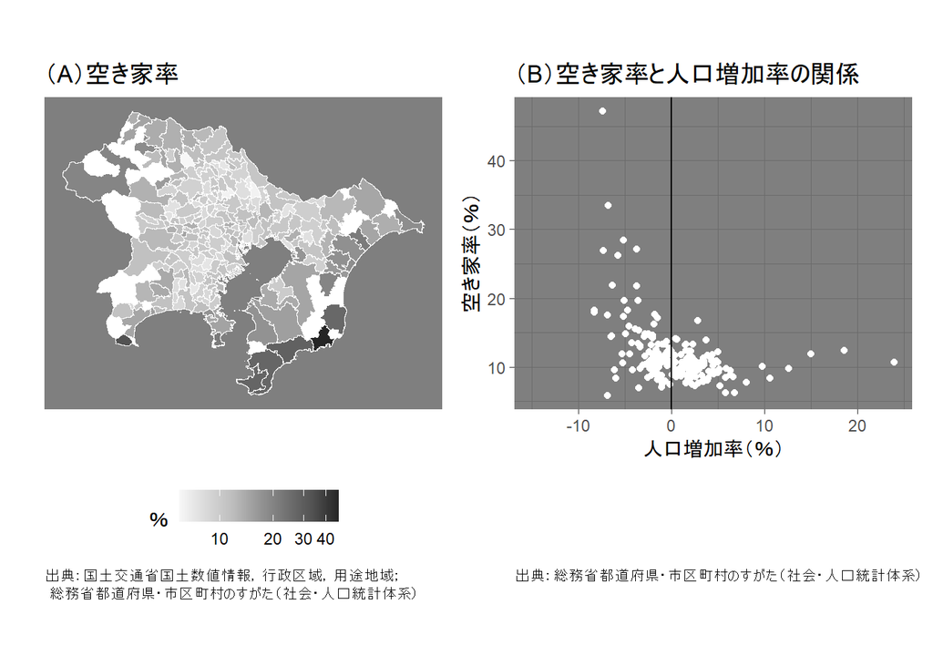

図9：1都3県市区町村別の空き家率（2018年度）と人口増加率（2015年度）

図$10$は，ある地域の既存住宅取引を示しています．図$3$とは異なり，図$10$の第$1$象限では需要曲線$D_0$と供給曲線$S_0$の交点が示されていません．そのため，価格がゼロでも供給量$H_2$が需要量$H_1$を上回る超過供給（空き家）が生じています．空き家を減らすには，価格が低下しなければなりません．しかし，価格はゼロより低くならないため，空き家が取り残されることになります．

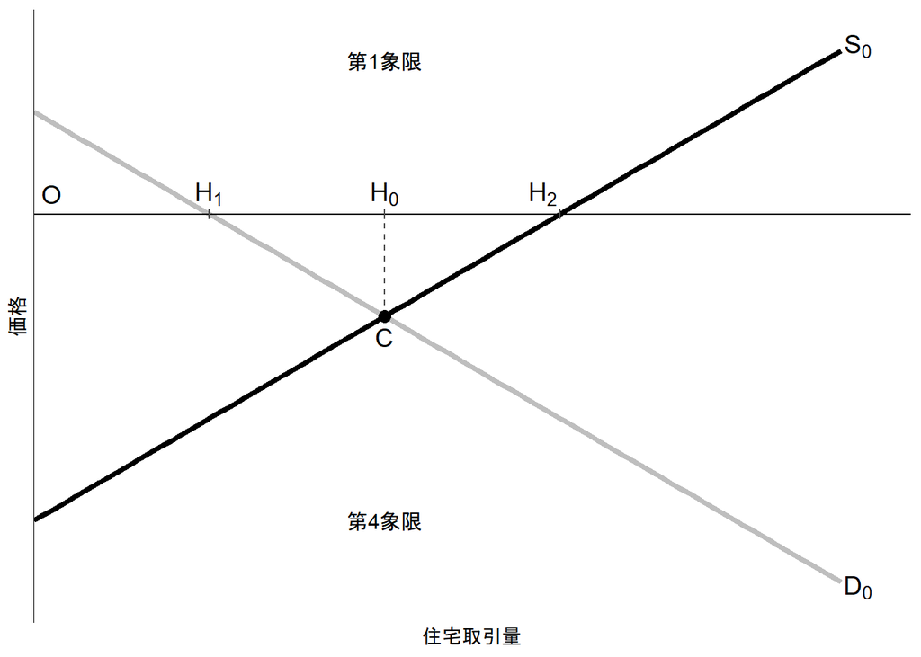

図10：空き家の価格分析

林（$1996$）にならい，需要曲線$D_0$と供給曲線$S_0$を図の第$4$象限に延ばしてみましょう（岩田，$2019$）．すると，需要曲線$D_0$と供給曲線$S_0$が$C$点において交わります．このことは，住宅価格がマイナスになることを意味します．マイナスの価格とは，買い手は価格が支払われると，住宅を引き取り，売り手は価格を支払うと，住宅を引き取ってもらえることを意味します．マイナスの価格は，縦軸を下に向かうほど，引き取り価格が高くなることを意味します．図$10$の第$4$象限でも需要曲線が右下がりであり続けるのは，引き取り価格が高くなれば，買い手が引き取ってもよい住宅が増えるからです．供給曲線が右上がりであり続けるのは，引き取り価格が高くなれば，住宅を引き取ってもらおうとする売り手の意欲が低下するからです．マイナス価格の下では，住宅取引量は$H_0$単位になり，空き家は発生していません．

どのようにすればマイナス価格を付けることができるでしょうか？家電リサイクル（家電廃棄物処理）市場の価格付けを考えてみましょう．家電リサイクル法施行以来，特定の家電製品はリサイクル料金を負担しなければ廃棄できなくなりました．この料金こそマイナスの価格を意味します．家電リサイクル同様に，住宅についてもリサイクル料金を設定することで，利用しない既存住宅の回収を進めることが可能になります．

## （2）賃貸価格と住宅価格

第$1$節でも述べたように，住宅は購入する家計もあれば賃貸する家計も存在します．住宅サービスの消費は賃貸することで得られるにも関わらず，なぜ住宅を購入する必要があるのでしょうか．その一つの考えは，住宅を投資の側面から考えることです．住宅を購入・所有する際に支払う住宅価格と住宅を賃貸する際に支払う賃貸価格（家賃）は利子率を通じて結びつきます．第$5$節（$2$）ではこのこと説明しましょう．

賃貸住宅は期限を限定して借りるのが一般的でしょう．ある限定された期間の家賃は，図$3$を賃貸住宅市場に置き換えると，市場需要曲線の市場供給量曲線の交点から導けます．

住宅を所有して，賃貸住宅市場でそれを運用すれば，家賃を収益として得ることができます．これが住宅を所有したときの投資側面になります．日本の家計の多くは購入した住宅に自ら居住し，家賃を獲得できないため，投資側面は一見存在しないように思われます．しかし，この場合は所有する住宅を自らの家計に貸し出し，自らから家賃を受け取っていると考えることができます（持ち家を所有すると家賃を支払わない分だけ得していると考えてもよいでしょう）．したがって，自らが居住する場合も投資側面があります．家計簿の上ではこの家賃の受け取りは計上されません．そこで，市場と決定される家賃と区別するため，自らが支払い，受け取る家賃を**帰属家賃**とよびます．いずれにしろ，住宅を所有する場合は，市場への貸し出しの有無に関わらず家賃という収益を獲得できることを意味します．

いま家計が$1$単位の住宅を購入するために住宅価格$P$の資金を用意していたとしましょう．この住宅を，ある一定期間所有すると（その期末に）賃貸価格$R$を得られるとします．住宅資産への投資とは別に，家計には金融資産への投資機会もあるのが一般的です．そこで，家計が用意していた資金$P$を住宅購入に充てず，金融資産で運用すると一定期間後（つまり期末）に元金$P$と利息$iP$を得られるとしましょう．ここで，$i$は利子率（$0≤i≤1$）を意味します．資産運用を考える家計は，高い収益を得られる方に資金を活用するでしょう．このような家計の投機行動は**裁定取引**とよばれます．仮に，一定期間後に

$$(1+i)P<R \label{a}\tag{5}$$
が成立するとしましょう．このとき，家計は資金をより高い収益が得られる住宅資産に投資するはずです．すなわち，住宅を購入して賃貸し，収益を得ようとします．住宅を購入しようとする家計の増加は，他の条件（賃貸価格$R$と利子率$i$）を一定として，住宅価格$P$の上昇を招きます．したがって，最初に用意していた資金では住宅を購入することはできません．ただし，$(\ref{a})$式の不等号が続く限り，投機行動は収まらず住宅価格の上昇が続きます．この投機行動が収まるのは，住宅資産と金融資産の収益が等しくなったときです．家計の裁定取引の結果，均衡では
$$(1+i)P=R \label{b}\tag{6}$$
が成り立つように住宅価格が上昇します．$(\ref{b})$式は，裁定取引によって収益を得られない条件を示しており，この条件を**無裁定条件**とよびます．[^1]$(\ref{b})$式から，住宅価格は

$$P=\frac {R}{(1+i)}　 \label{c}\tag{7}$$
になります．すなわち，現在の住宅価格はある一定期間で獲得できる賃貸価格$R$を$1＋$利子率で割り引くことによってもとめられます．このように将来得られる収益を現在の価値に直した値を**割引現在価値**とよびます．

それでは，仮に一定期間後に
$$(1+i)P>R$$
が成立する場合はどうでしょうか．この場合，家計は住宅資産への投資を控えるようになる結果，住宅価格$P$は$(\ref{c})$式が成立するように低下します．

住宅は耐久性があるため，一定期間終了後も賃貸価格を稼げるでしょう．そこで，最初の一定期間を期間$1$，次の一定期間を期間$2$とよび，期間$2$にも（その期末に）賃貸価格$R$を得られるとします．一方，資金を期限$1$に引き続き期限$2$も利子率$i$の金融資産で運用すると，元金は期限$1$終了後には$(1+i)$倍になり，期限$2$終了後にはその$(1+i)$倍になるため，$(1+i)^2$倍になります．このため，期間$2$に得られる賃貸価格$R$の割引現在価値は，
$$\frac {R}{(1+i)^2} \label{d}\tag{8}$$

になります．期間を延ばして考えてゆくと，期限$3$，期限$4$，・・・に得られる賃貸価格$R$の割引現在価値はそれぞれ，
$$\frac {R}{(1+i)^3}, \frac {R}{(1+i)^4}, ... \label{e}\tag{9}$$
になります．

住宅所有者は期限$1$には$(\ref{c})$式の右辺を，期限$2$には$(\ref{d})$式を，期限$3$，期限$4$，・・・には$(\ref{e})$式を得られるため，住宅を所有したときの賃貸価格収入の割引現在価値は次式のようになります．
$$P=\frac {R}{(1+i)}+\frac {R}{(1+i)^2}+\frac {R}{(1+i)^3} +\frac
{R}{(1+i)^4}+...　\label{f}\tag{10}$$

$(\ref{f})$式の両辺に$(1+i)$を掛け合わせると
$$(1+i)P=R+\frac {R}{(1+i)}+\frac {R}{(1+i)^2} +\frac {R}{(1+i)^3}+...
\label{g}\tag{11}$$
を得ます．

$(\ref{g})$式から$(\ref{f})$式を差し引くと住宅価格は次のように書き換えることができます．
$$P=\frac{R}{i} 　\label{h}\tag{12}$$
$(\ref{h})$式から，住宅価格はある一定期間の賃貸価格$R$と利子率$i$に依存することがわかります．また，賃貸価格の上昇や利子率の低下が住宅価格の上昇をもたらすことを確認できます．

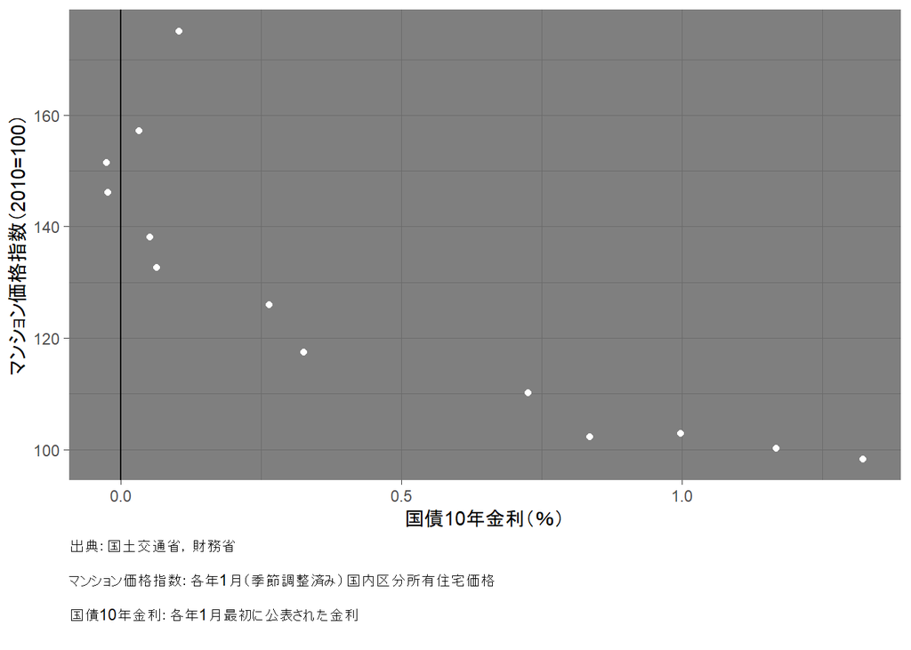

図11：2010年～2022年各年1月のマンション価格指数と国債金利の関係

日本では，住宅の取引だけではなく，土地の取引も行われます．土地の所有価格は地価とよばれ，土地の賃貸価格は地代とよばれます．住宅の所有価格と賃貸価格の関係同様に，地価は地代収入の割引現在価値で表現されます．地代の上昇や利子率の低下は地価の上昇をもたらします．

# 6 テキストガイド

本稿はミクロ経済学の需要と供給を応用して住宅市場を分析しました．ここでは，本稿同様にミクロ経済学を応用して住宅市場を分析しているミクロ経済学のテキストを紹介します．

- スティーヴン・レヴィット, オースタン・グールズビー, チャド・サイヴァーソン（安田洋祐監訳・高遠裕子訳）（$2017$）[『レヴィット ミクロ経済学 基礎編』](https://book.toyokeizai.net/textbook/book/?translated%5B%5D=translate4&s=&open=112)東洋経済新報社

このテキストではミクロ経済学の理論を紹介した後，その事例としてアメリカの住宅事情を取り上げている箇所があります．第$2$章では人口増加に伴う住宅需要の増加が住宅価格に与える影響を二つの都市（ニューヨークとヒューストン）の供給曲線の形状（**供給の価格弾力性**）の違いから分析しています．第$5$章では，住宅の床面積と年間家計所得の関係から，住宅の床面積が**正常財**になることを見ています．第$8$章では都市の大小に応じて住宅価格が異なるにもかかわらず，住宅仲介業者の年俸はほぼ一定になることを，企業の市場**参入**と**退出**の考え方を用いて説明しています．

このテキストには次の発展編があります．

- スティーヴン・レヴィット, オースタン・グールズビー, チャド・サイヴァーソン（安田洋祐監訳・高遠裕子訳）（$2018$）[『レヴィット ミクロ経済学 発展編』](https://book.toyokeizai.net/textbook/book/?translated%5B%5D=translate4&s=&open=112)東洋経済新報社

発展編でも住宅市場の例が取り上げられています．**一般均衡**を扱う第$14$章では，ある都市（ニューヨークとバッファロー）の労働需要の増加がその都市の雇用に及ぼす影響は，その都市の住宅供給の価格弾力性に依存することを紹介しています．**情報の非対称性**を扱う第$15$章では，住宅市場をよく知らない住宅の売り主が住宅仲介業者（エージェント）を雇って住宅を販売しようとすると，住宅は早く，安く売却される傾向にあることを説明しています．**行動経済学と実験経済学**を扱う第$17$章では，住宅価格下落時に住宅売却希望者が過去の購入額を気にするあまり，損失を被る住宅下落を受け入れない（**サンクコストの誤謬**）結果，市場に大量の売れ残りが生じた事実を紹介しています．

日本の住宅・土地市場については，次のミクロ経済学のテキストに応用例が多く含まれています．

- 八田達夫（$2008$）[『ミクロ経済学$\rm{I}$ 市場の失敗と政府の失敗への対策』](https://book.toyokeizai.net/textbook/book/?s=%E3%83%9F%E3%82%AF%E3%83%AD%E7%B5%8C%E6%B8%88%E5%AD%A6I)東洋経済新報社

価格規制を取り扱う第$1$章では，$1939$年の家賃統制，$1941$年に改正された借地借家法が，借家市場に大きな影響を与えたことを説明しています．家賃規制については下記のテキスト（$\rm{II}$）の第$15$章でも詳しく分析されています．第$9$章では，借家市場の入居差別について言及しています．家主にとって，借家人の家賃滞納は借家経営に関わる大きな問題です．このため，家主は家賃滞納の可能性が高い集団と契約したがりません（**統計的差別**）．この問題を解決する方法として，統計的差別を受ける借家人に借家を貸す家主に対して政府が家賃補助（**バウチャー**）を提供する方法を提案しています．

- 八田達夫（$2009$）[『ミクロ経済学$\rm{II}$ 効率化と格差是正』](https://book.toyokeizai.net/textbook/book/?s=%E3%83%9F%E3%82%AF%E3%83%AD%E7%B5%8C%E6%B8%88%E5%AD%A6I)東洋経済新報社

このテキストの第$12$章では，賃貸価格と売買価格について扱っています．その応用例として，土地市場，マンション市場，持ち家と借家の違いについて説明しています．効率性の観点から土地市場（第$14$章）や住宅市場（第$15$章）に対する課税を考えているのも特徴です．格差是正策を扱う第$22$章では使途指定**補助金**の例として住宅補助についてまとめています．

本稿では，住宅価格を考える際に，その値上がり（値下がり）益，住宅を所有した際にかかる税金，建物の劣化（資本減耗）については考えませんでした．住宅を所有する際には，家計は利子率，値上がり率，資本減耗率を考えるのが一般的です．経済学では，これらを足し合わせた値を**資本コスト**または**使用者費用**とよびます．これについては，次のテキストの第$5$章が参考になります．

- 佐藤泰裕（$2023$）[『都市・地域経済学への招待状 新版』](https://www.yuhikaku.co.jp/books/detail/9784641151192)有斐閣ストゥディア

# 参考文献

- 岩田真一郎（$2019$）[「空き家と高齢者の生活」](https://www.pref.toyama.jp/sections/1015/ecm/back/2019feb/tokushu/index1.html)『とやま経済月報』$2019$年$2$月号
- 高橋孝明（$2012$）[『都市経済学』](http://www.yuhikaku.co.jp/books/detail/9784641184060)有斐閣ブックス
- 林敏彦（$1996$）[『ハート＆マインド経済学入門』](http://www.yuhikaku.co.jp/books/detail/4641120226)有斐閣アルマ

# 補論（Rによるデータ分析）

## 関西2府1県の空き家率と人口増加率の相関

第$5$節（$1$）では，[総務省都道府県・市区町村のすがた（社会・人口統計体系）](https://www.e-stat.go.jp/regional-statistics/ssdsview)からダウンロードできる$1$都$3$県（東京都，埼玉県，千葉県，神奈川県，ただし東京都島嶼部は除きます）の$2018$年度と空き家率と$2015$年度の人口増減率の散布図（図$9$（$B$））を描きました．ここで，二つの変数の記述統計量は表$1$のようになります．

|  | 平均 | 標準偏差 | 最小値 | 最大値 | 観察数 |
| --- | --- | --- | --- | --- | --- |
| 空き家率（％） | 11.59 | 4.55 | 5.88 | 47.12 | 211 |
| 人口増減率（％） | -0.45 | 4.93 | -14.92 | 23.96 | 242 |

後ほど，表$1$と下記で作成する表$2$を比べます．

ここでは，関西$2$府$1$県（大阪府，京都府，兵庫県）の$2018$年度と空き家率と$2015$年度の人口増減率の散布図（図$9$（$B$））を描いてみましょう．まず，[総務省都道府県・市区町村のすがた（社会・人口統計体系）](https://www.e-stat.go.jp/regional-statistics/ssdsview)にアクセスし，データをダウンロードしましょう．`市区町村`を選択し，`データ表示`ボタンをクリックすると[データ表示（市区町村データ）](https://www.e-stat.go.jp/regional-statistics/ssdsview/municipality)のページに移ります．このページで地域を選択します．`任意の地域`のタブのまま`1絞り込み`で次を選択してください．

- `表示データ` > `現在の市区町村`
- `地域区分` > `都道府県` > `京都府`
- `絞り込み` > チェックのとおり

`地域区分`で`京都府`を選択すると`2地域候補`の`地域候補`欄に京都府の市区町村が表示されます．`全て選択する`ボタンをクリックすると，右の`選択中地域`欄に京都府の市区町村が表示されます．

続いて`地域区分`で`大阪府`を選択し，同様の作業を繰り返します．すると，`選択中地域`欄には京都府の市区町村の後に，大阪府の市区町村が示されます．最後に兵庫県についても同様の作業を繰り返します．この作業によって，`選択中地域`欄に京都府，大阪府，兵庫県の市区町村が選ばれているはずです．そこで`確定`ボタンをクリックしましょう．

クリックすると，`表示項目選択`と記された画面が現れます． このページの`1絞り込み`，`2項目候補`で次を選択してください．

- `データの種類` > `指標データ`
  - `分野` > `#H 居住`
- `項目候補` > `#H01405　空き家比率（％）`

`項目を選択`ボタンをクリックすると，右の`選択中項目`欄に選択した項目が表示されます．項目は最大$25$項目まで選択できます．したがって，人口増減率も選択できますが，ここでは空き家率だけを選択し，人口増減率は別途ダウンロードすることにします．

再び`確定`ボタンをクリックすると，データを表示する画面に移ります．`調査年`で調べたい年を表示できます．例えば，空き家比率の場合は，出典の『住宅・土地統計調査』から計算されています．このウェブサイトからは$2003$年度，$2008$年度，$2013$年度，$2018$年度の四回分のデータが納められています．ここでは，$2018$年度の空き家比率を選択することにします．このデータをダウンロードするために画面右上方向にある`ダウンロード`ボタンをクリックしましょう．

オプションを，

- `ダウンロードの範囲` > `ページ上部の選択項目`
- `ファイル形式` > `CSV形式(Shift-JIS)`
- `ヘッダの出力` > `出力しない`
- `コードの出力` > `出力する`
- `階層コードの出力` > `出力しない`
- `凡例の出力` > `出色しない`
  - `注釈を表示する` > チェックを外す
  - `データがない行を表示しない` > チェックのまま
  - `データがない列を表示しない` > チェックのまま
  - `桁区切り(,)を使用しない` > チェック

とし，ダウンロードしたファイルは例えば`R`を作業するフォルダー（ディレクトリ）に格納しましょう．ファイルは`FEI_CITY_`からはじまる名前がつけられています．なお，Windowsを使用している場合は，`CSV形式(Shift-JIS)`を選択することで，`R`上での文字化けを防ぐことができます．

空き家率（`空き家比率`）のデータはダウンロードできましたので，今度は人口増減率のデータをダウンロードし，同じ作業フォルダに格納します．変更点は，

- `データの種類` > `指標データ`
  - `分野` > `#A 人口・世帯`
- `項目候補` > `#A05101　人口増減率（％）`

になります．調査年は$2015$年度を使用することにします．

これでデータのダウンロードは終了しました．次に，散布図を描くためにデータを整えていきます．データがきちんと整っているかを確認するために，記述統計量を出力してみましょう．それでは，以下の`R`コードを`R`スクリプトに打ち込み確認ください．

```r
#データの整備・作成
library(tidyverse)

#2府1県の空き家率データ（csvファイル）の読込
#文字化けが発生する場合はfileEncoding="CP932"を指定
vacancy_kansai<-
  read.csv("FEI_CITY_230118120231.csv",
             sep=",", header=TRUE, skip=1,
           fileEncoding = "cp932")

#変数名（3列目と6列目）変更
vacancy_kansai %>%
  rename(city_code=3,
         vacancy_rate=6) ->
  vacancy_kansai

#2府1県の人口増減率データ（csvファイル）の読込
#文字化けが発生する場合はfileEncoding="CP932"を指定
pop_kansai<-
  read.csv("FEI_CITY_230119144444.csv",
             sep=",", header=TRUE, skip=1,
           fileEncoding = "cp932")

#変数名（3列目と6列目）変更
pop_kansai %>%
  rename(city_code=3,
         pop_rate=6) ->
  pop_kansai

#city_codeを用いて2つのデータの合併
vacancy_kansai<-
  left_join(vacancy_kansai, pop_kansai,
          by=c("city_code"))

#政令指定都市は市レベルではなく区レベルを使用
#京都市，大阪市，堺市，神戸市をデータから削除
vacancy_kansai %>%
  filter(city_code!=26100 & city_code!=27100 &
           city_code!=27140 & city_code!=28100) ->
  vacancy_kansai

#変数を文字列から数列に変更
vacancy_kansai %>%
  mutate(vacancy_rate=as.numeric(vacancy_rate),
         pop_rate=as.numeric(pop_rate)) ->
  vacancy_kansai

#記述統計量の表の作成
library(modelsummary)

#表2：関西2府1県記述統計量
datasummary(Heading("空き家率（％）")*vacancy_rate+
              Heading("人口増減率（％）")*pop_rate ~
              Heading("平均")*Mean+
              Heading("標準偏差")*SD+
              Heading("最小値")*Min+
              Heading("最大値")*Max+
              Heading("観察数")*N,
            data=vacancy_kansai,
            title="表2：関西2府1県記述統計量")
```

|  | 平均 | 標準偏差 | 最小値 | 最大値 | 観察数 |
| --- | --- | --- | --- | --- | --- |
| 空き家率（％） | 14.45 | 4.05 | 6.70 | 27.41 | 143 |
| 人口増減率（％） | -1.96 | 4.79 | -15.87 | 18.28 | 157 |

表$1$と表$2$を比べると，関西$2$府$1$県は関東$1$都$3$県より平均空き家率が高いことがうかがえます．ただし，関西$2$府$1$県は空き家率の最大値が$27.41$％と関東$1$都$3$県に比べると約$20$パーセントポイント低くなっています．

最後に，ここでの目的である関西$2$府$1$県は空き家率と人口増減率の散布図を描きます．以下の`R`コードを`R`スクリプトに打ち込んでください．

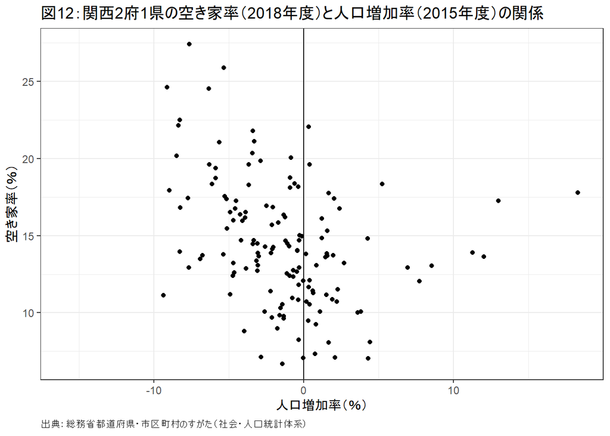

```r
#散布図の可視化
ggplot()+
  geom_point(data=vacancy_kansai,
             aes(x=pop_rate, y=vacancy_rate))+
  geom_vline(xintercept=0, linewidth=0.5)+
  labs(x="人口増加率（％）", y="空き家率（％）",
       caption="出典：総務省都道府県・市区町村のすがた（社会・人口統計体系）")+
  ggtitle("図12：関西2府1県の空き家率（2018年度）と人口増加率（2015年度）の関係")+
  theme_bw()+
  theme(plot.caption=element_text(hjust=0))
```

図$12$から，関西$2$府$1$県においても空き家率と人口増減率には負の相関関係がありそうです．ただし，人口増減率が高い地域で空き家率が$15$％周辺で高止まりしている様子もうかがえます．

# R環境

**セッション情報**

- R version 4.4.3 (2025-02-28 ucrt)
  - RStudio 2024.12.1+563
  - rmarkdown_2.29

**使用したパッケージ**

- `tidyverse`，`sf`，`patchwork`，`modelsummary`

# リンク

- [都市経済学講義ノート](https://shinichiro-iwata.github.io/lecture-notes-urban-econ/)
  - [都市内の住宅立地](https://shinichiro-iwata.github.io/lecture-notes-urban-econ/residential-location-choice.html)
- [Rによる地理空間データの可視化](https://shinichiro-iwata.github.io/geospatial-data-visualization/)
- [Shinichiro Iwata](https://shinichiro-iwata.github.io/)

**謝辞**

第$5$節（$2$）の裁定取引や無裁定条件について[岩木宏道](https://hiromichiiwaki.wixsite.com/personal)氏（神奈川大学経済学部）から貴重なアドバイスやコメントを頂戴しました．

**アイコン**

[Font Awesome](https://fontawesome.com/) 6.7.2

[^1]: 賃貸価格$R$，利子率$i$も変動して，裁定取引の機会が失われる場合も考えられます．まず，第$5$節（$2$）で考えてきたように投資側面から考えてみましょう．$(\ref{a})$式の不等号が成立するとき，家計は銀行から資金を借りて住宅を購入し，賃貸住宅として運用することで収益を得ることが可能です．この資金需要と住宅需要の増加により利子率と住宅価格が上昇します．一方で，賃貸供給の増加により賃貸価格が低下し，結果的に$(\ref{b})$式の無裁定条件に近づいていきます．次に，消費側面から考えてみましょう．現在，家計は賃貸住宅に対して$R$を支払っているとします．このとき，$(\ref{a})$式の不等号が成立していると，賃貸を続けるよりも住宅を購入した方が費用を抑えられます．そこで家計は銀行から資金を借りて住宅を購入し，賃貸を終了する選択をします．このようにして，資金需要と住宅需要の増加により利子率と住宅価格が上昇し，賃貸需要の減少により賃貸価格が低下します．そして，最終的には$(\ref{b})$式に収束していきます．説明方法は異なりますが，どちらの側面からも$(\ref{b})$式が成立します．